# Analyses for SII Experiment 5

### Sample Characteristics

On average, participants reported to be rather left leaning (M = 3.9, SD = 1.5 on a scale from 1 = left to 10 = right) and rather interested in politics (M = 6.3, SD = 2, on a scale ranging from 1 = not at all to 10 = very strongly).

### Manipulation check

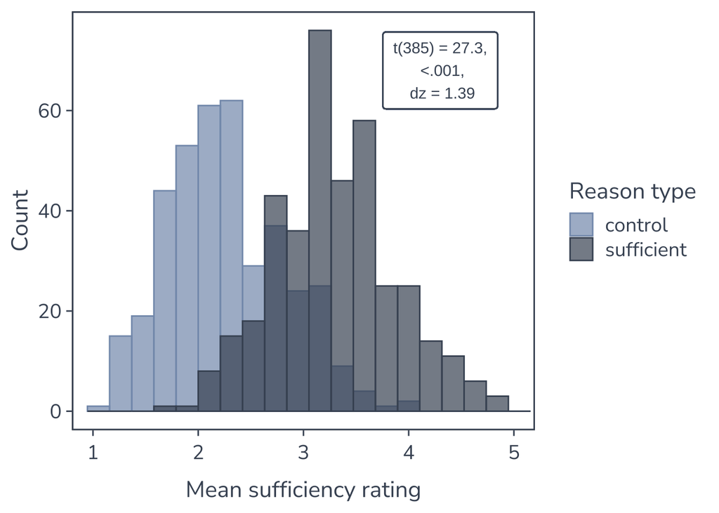

```r
check <- d_long %>%
  select(subject_id, reason_type, sufficiency) %>%
  group_by(subject_id, reason_type) %>%
  summarize(.groups = "drop", mn = mean(sufficiency, na.rm = TRUE))

# Descriptives
check_desc <- check %>%
  group_by(reason_type) %>%
  get_summary_stats(mn, type = "mean_sd") %>%
  rowwise() %>%
  mutate(across(c(mean, sd), forma))

# One-sided paired t-test
check_t <- check %>%
  t_test(
  mn ~ reason_type,
  paired = TRUE,
  alternative = "greater",
  ref.group = "sufficient") %>%
  mutate(p = formp(p), statistic = forma(statistic))

# Cohens dz
check_dz <- check %>%
  cohens_d(mn ~ reason_type, paired = TRUE, ref.group = "sufficient") %>%
  pull(effsize) %>%
  forma()

# Print t-test
check_report_plot <- paste0("t(", check_t$df, ") = ", check_t$statistic,
  ",\n ", check_t$p, ",\n dz = ", check_dz)
check_report_text <- paste0("t(", check_t$df, ") = ", check_t$statistic,
  ", ", check_t$p, ", d~z~ = ", check_dz)

# Plot results
check_plot <- check %>%
  ggplot(., aes(x = mn, fill = reason_type, color = reason_type)) +
  labs(x = "Mean sufficiency rating", y = "Count",
      fill = "Reason type", color = "Reason type") +
  scale_x_continuous(limits = c(1, 5), oob = scales::oob_keep) +
  geom_histogram(position = "identity", alpha = .7, bins = 20) +
  scale_fill_manual(values = c("#849AB9", "#465263")) +
  scale_color_manual(values = c("#849AB9", "#465263")) +
  geom_label(aes(x = 4.3, y = 68, label = check_report_plot),
    fill = "white", show.legend = FALSE,
    label.padding = unit(0.5, "lines"), label.size = 0.5) +
  theme_cs_talk()
check_plot
```

We included a manipulation check for reason type. The sufficient reasons are supposed to sufficiently explain the behaviors, whereas the control reasons are supposed to insufficiently explain the behavior (or not explain the behavior at all). We thus asked participants at the end of the study to rate the sufficiency of each reason for the respective behavior and expected the sufficient reasons to score higher than the control reasons. To test this, we conducted a paired t-test. On average, participants gave significantly higher sufficiency ratings in the sufficient condition (M = 3.30, SD = 0.57) than in the control condition (M = 2.28, SD = 0.56), t(385) = 27.3, <.001, d<sub>z</sub> = 1.39. We infer from this, that our manipulation of reason type worked.

### Preregistered analysis

```r
# Prepare error rate data
er <- d_long %>%
  select(subject_id, probe_type, reason_type, is_correct, stimulus_set) %>%
  group_by(probe_type, reason_type, stimulus_set, subject_id) %>%
  summarize(.groups = "drop_last",
    errors = sum(is_correct == 0),
    n_trials = n()) %>%
  mutate(er = errors / n_trials, .keep = "unused") %>%
  # Find extreme outliers
  mutate(is_extreme = is_extreme(er)) %>%
  ungroup() %T>%
  # Count participants that have extreme outliers
  assign(x = "er_ex_n", envir = .GlobalEnv, value = n_distinct(
    select(filter(., is_extreme == TRUE), subject_id)))

# Create data frame where these rows are excluded
er_ex <- filter(er, is_extreme == FALSE)

# Descriptives
er_3f_desc <- er_ex %>%
  select(stimulus_set, reason_type, probe_type, er) %>%
  group_by(stimulus_set, reason_type, probe_type) %>%
  get_summary_stats(er, type = "mean_sd") %>%
  mutate(
    ci95_low = mean - 1.96 * sd / sqrt(n),
    ci95_upp = mean + 1.96 * sd / sqrt(n))

# Run ANOVA
er_3f_mod <- er_ex %>%
  anova_test(dv = er, wid = subject_id, effect.size = "pes",
    within = c(probe_type, reason_type), between = stimulus_set) %>%
  as_tibble() %>%
  rowwise() %>%
  mutate(F = forma(`F`, 2), p = formp(p), pes = forma(pes, 3, FALSE))

# Run post-hoc tests
er_3f_post <- er_ex %>%
  group_by(stimulus_set) %>%
  anova_test(dv = er, wid = subject_id, effect.size = "pes",
    within = c(probe_type, reason_type)) %>%
  as_tibble() %>%
  rowwise() %>%
  mutate(F = forma(`F`, 2), p = formp(p), pes = forma(pes, 3, FALSE))
```

We calculated false recognition rates by dividing the number of erroneous responses by six (the number of trials per condition).

#### Outlier detection

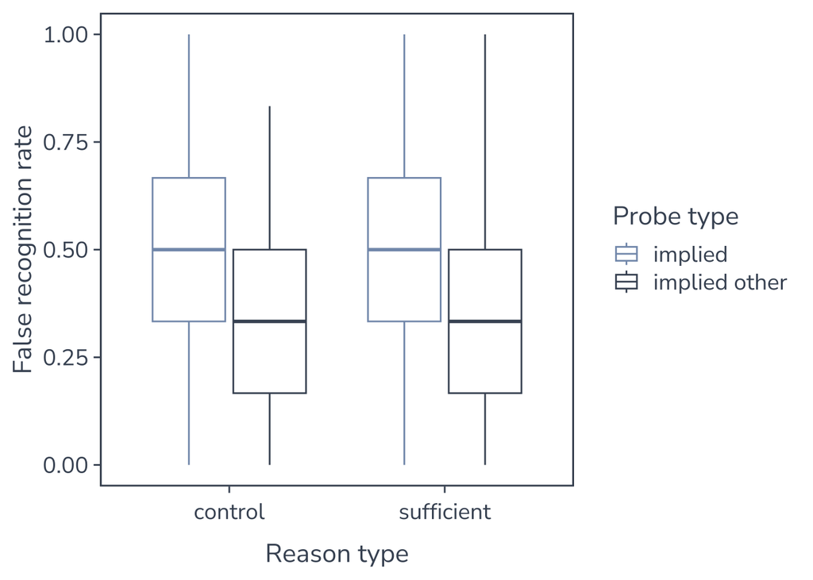

```r
er_outlier <- er_ex %>%
  ggplot(., aes(reason_type, er, color = probe_type)) +
  geom_boxplot() +
  labs(x = "Reason type", y = "False recognition rate",
    color = "Probe type") +
  scale_color_manual(values = c("#849AB9", "#465263")) +
  geom_point(
    # Replace all non-outlier values by NA
    data = mutate(er, er = replace(er, is_extreme == FALSE, NA)),
    position = position_dodge(width = 0.75), shape = 4,
    size = 4, show.legend = FALSE) +
  theme_cs_talk()
er_outlier
```

We looked for extreme outliers in each cell of the design. We defined them as values above Q3 + 3 * IQR or below Q1 - 3 * IQR. We found and excluded 0 participants whose values were extreme outliers.

#### QQ-Plot

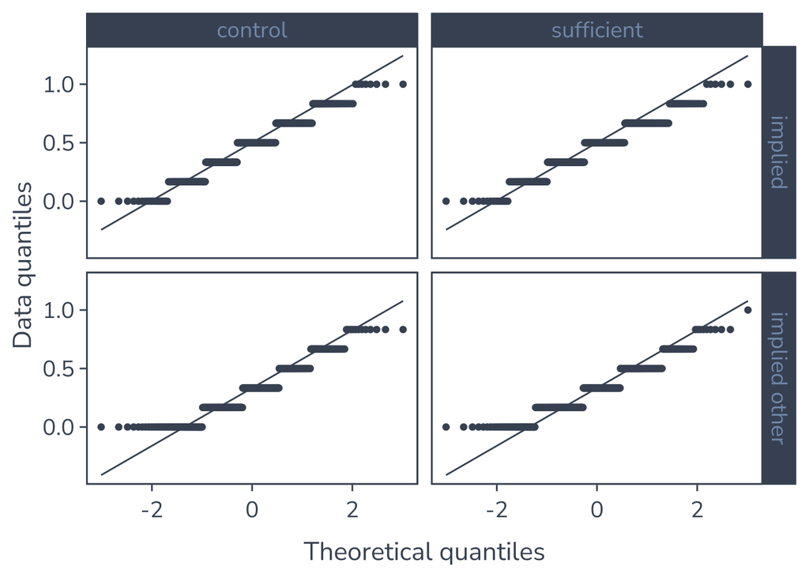

```r
er_qq <- er_ex %>%
  ggplot(., aes(sample = er)) +
  labs(x = "Theoretical quantiles", y = "Data quantiles") +
  stat_qq(color = "#465263") +
  stat_qq_line(color = "#465263") +
  facet_grid(probe_type ~ reason_type, labeller = "label_value") +
  theme_cs_talk()
er_qq
```

Upon visual inspection the distributions of error rates in the different conditions did not seem severely non-normal. We therefore applied no further transformations before conducting our analysis.

#### ANOVA

```r
knitr::kable(er_3f_mod, format = "markdown")
```

| Effect | DFn | DFd | F | p | p<.05 | pes |
| --- | --- | --- | --- | --- | --- | --- |
| stimulus_set | 1 | 384 | 8.40 | .004 | * | .021 |
| probe_type | 1 | 384 | 221.48 | <.001 | * | .366 |
| reason_type | 1 | 384 | 0.02 | .897 |  | .000 |
| stimulus_set:probe_type | 1 | 384 | 17.99 | <.001 | * | .045 |
| stimulus_set:reason_type | 1 | 384 | 0.05 | .826 |  | .000 |
| probe_type:reason_type | 1 | 384 | 1.70 | .193 |  | .004 |
| stimulus_set:probe_type:reason_type | 1 | 384 | 5.47 | .020 | * | .014 |

However, there were unexpected effects involving the stimulus set. First, there was a small but significant main effect of stimulus set, F(1, 384) = 8.40, p = .004, $\eta_{p}^{2}$ = .021, indicating higher overall error rates in stimulus set B. Second, there was a significant interaction between stimulus set and probe type, F(1, 384) = 17.99, p < .001, $\eta_{p}^{2}$ = .045, with larger inference effects in stimulus set B. Lastly, there was a significant three-way interaction, F(1, 384) = 5.47, p = .020, $\eta_{p}^{2}$ = .014, indicating a larger discounting effect in stimulus set B.

#### Descriptives

```r
knitr::kable(er_3f_desc, format = "markdown")
```

| stimulus_set | reason_type | probe_type | variable | n | mean | sd | ci95_low | ci95_upp |
| --- | --- | --- | --- | --- | --- | --- | --- | --- |
| A | control | implied | er | 196 | 0.422 | 0.226 | 0.3903600 | 0.4536400 |
| A | control | implied other | er | 196 | 0.323 | 0.219 | 0.2923400 | 0.3536600 |
| A | sufficient | implied | er | 196 | 0.435 | 0.218 | 0.4044800 | 0.4655200 |
| A | sufficient | implied other | er | 196 | 0.316 | 0.196 | 0.2885600 | 0.3434400 |
| B | control | implied | er | 190 | 0.529 | 0.220 | 0.4977175 | 0.5602825 |
| B | control | implied other | er | 190 | 0.297 | 0.217 | 0.2661440 | 0.3278560 |
| B | sufficient | implied | er | 190 | 0.492 | 0.204 | 0.4629926 | 0.5210074 |
| B | sufficient | implied other | er | 190 | 0.332 | 0.209 | 0.3022816 | 0.3617184 |

#### Lineplot

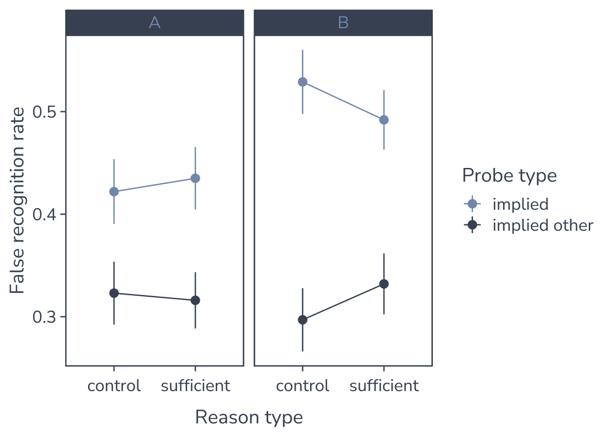

```r
er_lineplot <- er_3f_desc %>%
  ggplot(., aes(reason_type, mean, color = probe_type, group = probe_type)) +
  facet_wrap(. ~ stimulus_set, labeller = "label_value") +
  labs(x = "Reason type", y = "False recognition rate",
    color = "Probe type") +
  scale_color_manual(values = c("#849AB9", "#465263")) +
  geom_line() +
  geom_point(size = 3) +
  geom_linerange(aes(ymin = ci95_low, ymax = ci95_upp)) +
  theme_cs_talk()
er_lineplot
```

#### Post-hoc tests

```r
knitr::kable(er_3f_post, format = "markdown")
```

| stimulus_set | Effect | DFn | DFd | F | p | p<.05 | pes |
| --- | --- | --- | --- | --- | --- | --- | --- |
| A | probe_type | 1 | 195 | 61.19 | <.001 | * | .239 |
| A | reason_type | 1 | 195 | 0.06 | .806 |  | .000 |
| A | probe_type:reason_type | 1 | 195 | 0.52 | .472 |  | .003 |
| B | probe_type | 1 | 189 | 169.54 | <.001 | * | .473 |
| B | reason_type | 1 | 189 | 0.00 | .949 |  | .000 |
| B | probe_type:reason_type | 1 | 189 | 6.86 | .010 | * | .035 |

### Comparison between studies

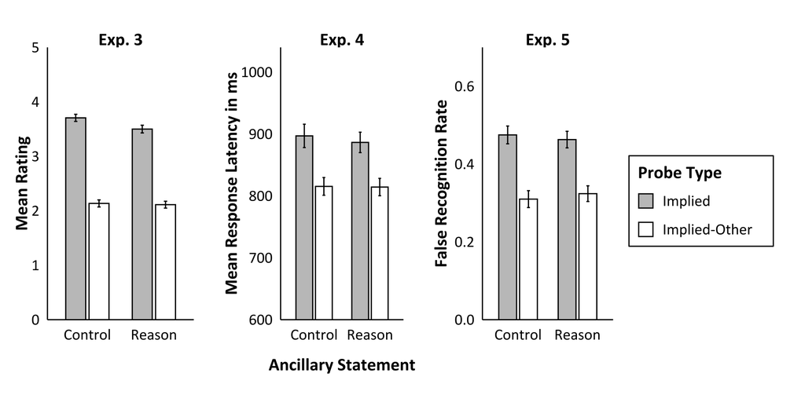

```r
load(here::here("Processed data/desc_SII2b.RData"))
load(here::here("Processed data/desc_SII2.RData"))
desc_SII3 <- er_ex %>%
  select(reason_type, probe_type, er) %>%
  group_by(reason_type, probe_type) %>%
  get_summary_stats(er, type = "mean_sd") %>%
  mutate(
    ci95_low = mean - 1.96 * sd / sqrt(n),
    ci95_upp = mean + 1.96 * sd / sqrt(n),
    experiment = "Exp. 5",
    ancillary_statement = recode(reason_type, "sufficient" = "Reason", "control" = "Control"),
    probe_type = recode(probe_type, "implied" = "Implied", "implied other" = "Implied-Other"))
desc_SII2b <- desc_SII2b %>%
  mutate(
    ancillary_statement = recode(reason_type, "sufficient" = "Reason", "control" = "Control"),
    probe_type = recode(probe_type, "implied" = "Implied", "implied other" = "Implied-Other"))
desc_SII2 <- desc_SII2 %>%
  mutate(
    ancillary_statement = recode(reason_type, "sufficient" = "Reason", "control" = "Control"),
    probe_type = recode(probe_type, "implied" = "Implied", "implied other" = "Implied-Other"))

p1 <- desc_SII2b %>%
  ggplot(., aes(x = ancillary_statement, y = mean, fill = probe_type)) +
  facet_wrap(. ~ experiment, labeller = "label_value") +
  labs(x = "", y = "Mean Rating",
    fill = "Probe Type") +
  scale_fill_manual(values = c("#c4c4c4", "#ffffff")) +
  scale_y_continuous(expand = c(0, 0)) +
  coord_cartesian(ylim = c(0, 5)) +
  geom_bar(stat = "identity", position = position_dodge(0.7),
    color = "#000000", width = 0.6) +
  geom_errorbar(aes(ymin = ci95_low, ymax = ci95_upp),
    position = position_dodge(0.7), width = 0.1) +
  theme_cs_apa() +
  theme(legend.position = "none", panel.border = element_blank())

p2 <- desc_SII2 %>%
  ggplot(., aes(x = ancillary_statement, y = mean, fill = probe_type)) +
  facet_wrap(. ~ experiment, labeller = "label_value") +
  labs(x = "Ancillary Statement", y = "Mean Response Latency in ms",
    fill = "Probe Type") +
  scale_fill_manual(values = c("#c4c4c4", "#ffffff")) +
  scale_y_continuous(expand = c(0, 0)) +
  coord_cartesian(ylim = c(600, 1040)) +
  geom_bar(stat = "identity", position = position_dodge(0.7),
    color = "#000000", width = 0.6) +
  geom_errorbar(aes(ymin = ci95_low, ymax = ci95_upp),
    position = position_dodge(0.7), width = 0.1) +
  theme_cs_apa() +
  theme(legend.position = "none", panel.border = element_blank())

p3 <- desc_SII3 %>%
  ggplot(., aes(x = ancillary_statement, y = mean, fill = probe_type)) +
  facet_wrap(. ~ experiment, labeller = "label_value") +
  labs(x = "", y = "False Recognition Rate",
    fill = "Probe Type") +
  scale_fill_manual(values = c("#c4c4c4", "#ffffff")) +
  scale_y_continuous(expand = c(0, 0)) +
  coord_cartesian(ylim = c(0, 0.7)) +
  geom_bar(stat = "identity", position = position_dodge(0.7),
    color = "#000000", width = 0.6) +
  geom_errorbar(aes(ymin = ci95_low, ymax = ci95_upp),
    position = position_dodge(width = 0.7), width = 0.1) +
  theme_cs_apa() +
  theme(panel.border = element_blank()) +
  guides(fill = guide_legend(byrow = TRUE))

p <- ggarrange(p1, p2, p3, ncol = 3, nrow = 1,
  legend.grob = get_legend(p3), legend = "right")
p
```

### Exploratory multilevel analysis

```r
d_mlm <- d_long %>%
  select(
    subject_id, item_id, probe_type, reason_type, is_correct,
    sufficiency, gender, age, pol_orientation, pol_interest) %>%
  mutate(.keep = "unused",
    is_error = abs(1 - is_correct),
    gender = ifelse(gender %in% c("other", "not specified"), NA, gender),
    # Grand mean center level 2 predictors
    age = age - mean(age),
    pol_orientation = pol_orientation - mean(pol_orientation),
    pol_interest = pol_interest - mean(pol_interest),
    probe_type = relevel(probe_type, ref = "implied other")
  ) %>%
  group_by(subject_id) %>%
  mutate(
    sufficiency = sufficiency - mean(sufficiency),
    response = factor(ifelse(
      is_error == TRUE,
      "false recognitions",
      "correct rejections"))) %>%
  mutate(response = factor(response, levels = rev(levels(response)))) %>%
  ungroup()
```

We performed an exploratory multilevel analysis to investigate whether the ratings regarding the sufficiency of the reasons could explain the strength of the SII-effect.

```r
mlm1 <- lme4::glmer(is_error ~ probe_type * reason_type +
  (1 | subject_id) + (1 | item_id),
  data = d_mlm,
  family = binomial(link = "logit"),
  control = glmerControl(optimizer = "bobyqa"))
mlm2 <- lme4::glmer(is_error ~ probe_type * sufficiency +
  (1 | subject_id) + (1 | item_id),
  data = d_mlm,
  family = binomial(link = "logit"),
  control = glmerControl(optimizer = "bobyqa"))
```

We ran two models. Each model had a random effect for participant and item. In Model I we predicted the binary response variable (correct rejection versus false recognition) by probe type and reason type. Only probe type was significant. In Model II we used sufficiency rather than reason type as a predictor. There was a significant effect of probe type, with the probability of a false recognition being higher for implied compared to implied-other probes. There was a marginally significant effect of sufficiency, with higher sufficiency ratings predicting a higher probability of a false recognition. Lastly, there was a significant interaction with an increase of sufficiency predicting a lower probability of a false recognition for implied probes.

#### Model I

|  | is_error |  |  |
| --- | --- | --- | --- |
| Predictors | Odds Ratios | CI | p |
| (Intercept) | 0.42 | 0.35 – 0.52 | **<0.001** |
| probe type [implied] | 2.11 | 1.86 – 2.39 | **<0.001** |
| reason type [sufficient] | 1.06 | 0.93 – 1.20 | 0.370 |
| probe type [implied] × reason type [sufficient] | 0.90 | 0.75 – 1.07 | 0.222 |
| Random Effects |  |  |  |
| σ<sup>2</sup> | 3.29 |  |  |
| τ<sub>00</sub> <sub>subject_id</sub> | 0.18 |  |  |
| τ<sub>00</sub> <sub>item_id</sub> | 0.19 |  |  |
| ICC | 0.10 |  |  |
| N <sub>subject_id</sub> | 386 |  |  |
| N <sub>item_id</sub> | 24 |  |  |
| Observations | 9264 |  |  |
| Marginal R<sup>2</sup> / Conditional R<sup>2</sup> | 0.032 / 0.129 |  |  |

#### Model II

|  | is_error |  |  |
| --- | --- | --- | --- |
| Predictors | Odds Ratios | CI | p |
| (Intercept) | 0.44 | 0.36 – 0.53 | **<0.001** |
| probe type [implied] | 2.00 | 1.83 – 2.18 | **<0.001** |
| sufficiency | 1.05 | 1.00 – 1.10 | 0.054 |
| probe type [implied] × sufficiency | 0.90 | 0.85 – 0.96 | **0.001** |
| Random Effects |  |  |  |
| σ<sup>2</sup> | 3.29 |  |  |
| τ<sub>00</sub> <sub>subject_id</sub> | 0.18 |  |  |
| τ<sub>00</sub> <sub>item_id</sub> | 0.19 |  |  |
| ICC | 0.10 |  |  |
| N <sub>subject_id</sub> | 386 |  |  |
| N <sub>item_id</sub> | 24 |  |  |
| Observations | 9264 |  |  |
| Marginal R<sup>2</sup> / Conditional R<sup>2</sup> | 0.033 / 0.130 |  |  |

#### Visualization sufficiency

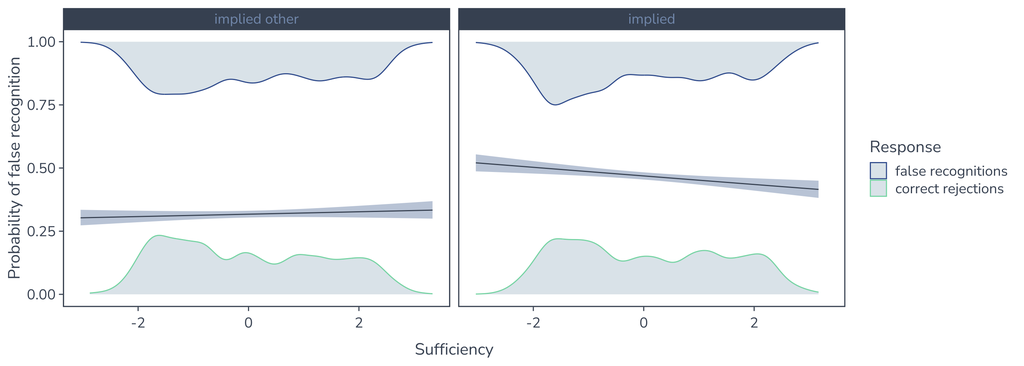

```r
mlm_sufficiency <- d_mlm %>%
  ggplot(., aes(x = sufficiency, y = is_error)) +
  facet_grid(~ probe_type, labeller = "label_value") +
  labs(
    y = "Probability of false recognition",
    x = "Sufficiency", color = "Response") +
  stat_smooth(
    method = "glm", size = 0.5, se = TRUE, level = 0.95,
    color = "#465263", fill = "#849AB9", alpha = 0.5,
    method.args = list(family = binomial)) +
  stat_slab(aes(y = is_error,
    side = ifelse(is_error == 1, "bottom", "top"),
    color = response), fill = "#E0E8ED", alpha = 1,
    slab_type = "pdf", scale = 0.25, size = 0.5) +
  scale_color_viridis_d(option = "mako", begin = 0.4, end = 0.85) +
  theme_cs_talk()
mlm_sufficiency
```

```r
ggexport(check_plot, width = 6, height = 5,
  filename = here::here("Analysis/check.pdf"))
ggexport(er_outlier, width = 7, height = 5,
  filename = here("Analysis/er-outlier.pdf"))
ggexport(er_qq, width = 7, height = 7,
  filename = here("Analysis/er-qq.pdf"))
ggexport(er_lineplot, width = 8, height = 5,
  filename = here::here("Analysis/er-lineplot.pdf"))
ggexport(mlm_sufficiency, width = 8, height = 5,
  filename = here::here("Analysis/mlm-sufficiency.pdf"))
ggexport(p, width = 13, height = 5,
  filename = here::here("Analysis/exp-345-barplot.pdf"))
```